# Ford GoBike Data Exploration

## by Emefiele-konyeri Awinrin

1. Introduction
1. Preliminary Wrangling

   2.1 Gathering Data

   2.2 Assessing Data

   2.2.1 Quality Issues

   2.2.2 Tidiness Issues
1. Cleaning Data
1. Storing Data
1. Analyzing and Visualizing Data

   5.1 Univariate Exploration

   5.1.1 Insights Gained For Univariate Exploration

   5.2 Bivariate Exploration

   5.2.1 Insights Gained For Univariate Exploration

   5.3 Multivariate Exploration

   5.3.1 Insights Gained For Univariate Exploration

   5.4 Conclusions

## Introduction

Ford, in collaboration with Motivate, is launching Ford GoBike – a regional bike-share network designed to enhance sustainable transportation in the San Francisco Bay Area. Ford GoBike is the Bay Area’s newest sustainable transportation option. The system will serve San Francisco, San Jose, Oakland, Berkeley and Emeryville and rapidly grow to 7,000 bikes at 546 stations by the end of 2018. The first three months of 2019 datasets were downloaded from a [baywheels-data](https://s3.amazonaws.com/baywheels-data/index.html) hosted on [AWS](https://s3.amazonaws.com/)(amazon web services), the three dataset will be joined together has one dataset since they are of the same structure. These datasets will be wrangled for proper exploration of the data, analysed to find patterns and trends, and visualize the insights gained through charts and graphs.

## Preliminary Wrangling

```python
# import all packages and set plots to be embedded inline
import numpy as np
import pandas as pd
import matplotlib.pyplot as plt
from matplotlib.dates import DateFormatter
import matplotlib.dates as mdates
import seaborn as sb
from pandas.api.types import CategoricalDtype

%matplotlib inline
```

> Load in your dataset and describe its properties through the questions below. Try and motivate your exploration goals through this section.

## Gathering Data

```python
# Data downloaded from AWS
bikeshare1 = pd.read_csv('201901-fordgobike-tripdata.csv')
bikeshare2 = pd.read_csv('201902-fordgobike-tripdata.csv')
bikeshare3 = pd.read_csv('201903-fordgobike-tripdata.csv')
```

```python
bikeshare1.shape
```

```
(192082, 14)
```

```python
bikeshare2.shape
```

```
(183412, 14)
```

```python
bikeshare3.shape
```

```
(256299, 14)
```

> The three datasets will be concatenated accordingly based on the order of month

```python
bikeshare = pd.concat([bikeshare1,bikeshare2,bikeshare3])
bikeshare.shape
```

```
(631793, 14)
```

> Now we have a total of 631793 observations and 14 attributes of the `bikeshare` dataset

## Assessing Data

```python
# loading the bikeshare data for visual assessment
bikeshare.head(5).T
```

|  | 0 | 1 | 2 | 3 | 4 |
| --- | --- | --- | --- | --- | --- |
| duration_sec | 80825 | 65900 | 62633 | 44680 | 60709 |
| start_time | 2019-01-31 17:57:44.6130 | 2019-01-31 20:58:33.8860 | 2019-01-31 18:06:52.9240 | 2019-01-31 19:46:09.7190 | 2019-01-31 14:19:01.5410 |
| end_time | 2019-02-01 16:24:49.8640 | 2019-02-01 15:16:54.1730 | 2019-02-01 11:30:46.5300 | 2019-02-01 08:10:50.3180 | 2019-02-01 07:10:51.0650 |
| start_station_id | 229.0 | 4.0 | 245.0 | 85.0 | 16.0 |
| start_station_name | Foothill Blvd at 42nd Ave | Cyril Magnin St at Ellis St | Downtown Berkeley BART | Church St at Duboce Ave | Steuart St at Market St |
| start_station_latitude | 37.775745 | 37.785881 | 37.870139 | 37.770083 | 37.79413 |
| start_station_longitude | -122.213037 | -122.408915 | -122.268422 | -122.429156 | -122.39443 |
| end_station_id | 196.0 | 134.0 | 157.0 | 53.0 | 28.0 |
| end_station_name | Grand Ave at Perkins St | Valencia St at 24th St | 65th St at Hollis St | Grove St at Divisadero | The Embarcadero at Bryant St |
| end_station_latitude | 37.808894 | 37.752428 | 37.846784 | 37.775946 | 37.787168 |
| end_station_longitude | -122.25646 | -122.420628 | -122.291376 | -122.437777 | -122.388098 |
| bike_id | 4861 | 5506 | 2717 | 4557 | 2100 |
| user_type | Subscriber | Subscriber | Customer | Customer | Customer |
| bike_share_for_all_trip | No | No | No | No | No |

```python
bikeshare.info()
```

```
<class 'pandas.core.frame.DataFrame'>
Int64Index: 631793 entries, 0 to 256298
Data columns (total 14 columns):
 #   Column                   Non-Null Count   Dtype
---  ------                   --------------   -----
 0   duration_sec             631793 non-null  int64
 1   start_time               631793 non-null  object
 2   end_time                 631793 non-null  object
 3   start_station_id         631127 non-null  float64
 4   start_station_name       631127 non-null  object
 5   start_station_latitude   631793 non-null  float64
 6   start_station_longitude  631793 non-null  float64
 7   end_station_id           631127 non-null  float64
 8   end_station_name         631127 non-null  object
 9   end_station_latitude     631793 non-null  float64
 10  end_station_longitude    631793 non-null  float64
 11  bike_id                  631793 non-null  int64
 12  user_type                631793 non-null  object
 13  bike_share_for_all_trip  631793 non-null  object
dtypes: float64(6), int64(2), object(6)
memory usage: 72.3+ MB
```

```python
bikeshare.duplicated().sum()
```

```
0
```

```python
bikeshare.isnull().sum()
```

```
duration_sec                 0
start_time                   0
end_time                     0
start_station_id           666
start_station_name         666
start_station_latitude       0
start_station_longitude      0
end_station_id             666
end_station_name           666
end_station_latitude         0
end_station_longitude        0
bike_id                      0
user_type                    0
bike_share_for_all_trip      0
dtype: int64
```

> We have 666 observations without station name and station id from the start of the ride to the end of the ride. There would have to be some questions asked to be able to detect why station name and station id are missing, but since we don't have any information regarding this,the 666 observations would be droppped

### Quality Issues

1. Erroneous data types: `start_time`,`end_time`,`start_station_id`, `end_station_id` and `bike_id`
2. Missing records in `start_station_id`,`end_station_id`,`start_station_name` and `end_station_name`

### Tidiness Issues

> Geographical area is also a factor that influences the operations of the bikeshare system, it can be useful in these case study to understand how the bikeshare system is developing in each geographical area. We can get this data by leveraging the coordinates given as attributes.

## Cleaning Data

```python
# Making a copy of original piece of data
bikeshare_clean = bikeshare.copy()
```

#### Define:

1. Erroneous data types: `start_time`,`end_time`,`start_station_id`, `end_station_id` and `bike_id`
2. Missing records in `start_station_id`,`end_station_id`,`start_station_name` and `end_station_name`
3. Neighbourhood and City attributes will be created using the coordinates attributes

#### Code for defined issue `1`

```python
# changing strings to datetime and int to strings
bikeshare_clean['start_time'] = pd.to_datetime(bikeshare_clean['start_time'])
bikeshare_clean['end_time'] = pd.to_datetime(bikeshare_clean['end_time'])
bikeshare_clean['start_station_id'] = bikeshare_clean['start_station_id'].astype(str).str[:-2]
bikeshare_clean['end_station_id'] = bikeshare_clean['end_station_id'].astype(str).str[:-2]
bikeshare_clean['bike_id'] = bikeshare_clean['bike_id'].astype(str)
```

#### Test

```python
bikeshare_clean.info()
```

```
<class 'pandas.core.frame.DataFrame'>
Int64Index: 631793 entries, 0 to 256298
Data columns (total 14 columns):
 #   Column                   Non-Null Count   Dtype
---  ------                   --------------   -----
 0   duration_sec             631793 non-null  int64
 1   start_time               631793 non-null  datetime64[ns]
 2   end_time                 631793 non-null  datetime64[ns]
 3   start_station_id         631793 non-null  object
 4   start_station_name       631127 non-null  object
 5   start_station_latitude   631793 non-null  float64
 6   start_station_longitude  631793 non-null  float64
 7   end_station_id           631793 non-null  object
 8   end_station_name         631127 non-null  object
 9   end_station_latitude     631793 non-null  float64
 10  end_station_longitude    631793 non-null  float64
 11  bike_id                  631793 non-null  object
 12  user_type                631793 non-null  object
 13  bike_share_for_all_trip  631793 non-null  object
dtypes: datetime64[ns](2), float64(4), int64(1), object(7)
memory usage: 72.3+ MB
```

#### Code for defined issue `2`

```python
# dropping null values
bikeshare_clean = bikeshare_clean.dropna()
```

#### Test

```python
bikeshare_clean.isnull().sum()
```

```
duration_sec               0
start_time                 0
end_time                   0
start_station_id           0
start_station_name         0
start_station_latitude     0
start_station_longitude    0
end_station_id             0
end_station_name           0
end_station_latitude       0
end_station_longitude      0
bike_id                    0
user_type                  0
bike_share_for_all_trip    0
dtype: int64
```

#### Code for defined issue `3`

```python
# using the geopy python library to locate areas based on the coordinates provided
from geopy.geocoders import Nominatim
from geopy.extra.rate_limiter import RateLimiter
from geopy.distance import geodesic

geolocator = Nominatim(user_agent="bikeshare")
reverse = RateLimiter(geolocator.reverse, min_delay_seconds=1, max_retries=0)
```

```python
# removing duplicate start station ids to get each station's unique coordinates
bikeshare_start = bikeshare_clean[['start_station_id','start_station_name','start_station_latitude',
                      'start_station_longitude']].drop_duplicates(subset = ['start_station_id'])
bikeshare_start.set_index('start_station_id',inplace=True)
```

[output not shown]

347 rows × 3 columns

```python
# removing duplicate end station ids to get each station's unique coordinates
bikeshare_end = bikeshare_clean[['end_station_id','end_station_name','end_station_latitude',
                      'end_station_longitude']].drop_duplicates(subset = ['end_station_id'])
bikeshare_end.set_index('end_station_id',inplace=True)
bikeshare_end
```

| end_station_id | end_station_name | end_station_latitude | end_station_longitude |
| --- | --- | --- | --- |
| 196 | Grand Ave at Perkins St | 37.808894 | -122.256460 |
| 134 | Valencia St at 24th St | 37.752428 | -122.420628 |
| 157 | 65th St at Hollis St | 37.846784 | -122.291376 |
| 53 | Grove St at Divisadero | 37.775946 | -122.437777 |
| 28 | The Embarcadero at Bryant St | 37.787168 | -122.388098 |
| ... | ... | ... | ... |
| 395 | Kerley Dr at Rosemary St | 37.360854 | -121.906834 |
| 392 | Sonora Ave at 1st St | 37.364060 | -121.911732 |
| 405 | Sunol St at San Carlos St | 37.323451 | -121.905976 |
| 402 | Raymond Bernal Jr Memorial Park (8th St at Hed... | 37.356834 | -121.895936 |
| 396 | Metro Dr at Technology Dr | 37.367678 | -121.918794 |

347 rows × 3 columns

```python
# using the itertuples function to iterate rows and columns in order to get each coordinate pair
start_locations = []
for row in bikeshare_start.itertuples():
    start_locations.append(reverse("{},{}".format(row.start_station_latitude,row.start_station_longitude)).raw['address'])
```

```python
# using the itertuples function to iterate rows and columns in order to get each coordinate pair
end_locations = []
for row in bikeshare_end.itertuples():
    end_locations.append(reverse("{},{}".format(row.end_station_latitude,row.end_station_longitude)).raw['address'])
```

```python
# An example of the data that is being retrieved from a server using geopy
reverse('37.775745,-122.213037').raw['address']
```

```
{'house_number': '4200',
 'road': 'Foothill Boulevard',
 'neighbourhood': 'Melrose',
 'city': 'Oakland',
 'county': 'Alameda County',
 'state': 'California',
 'ISO3166-2-lvl4': 'US-CA',
 'postcode': '94601',
 'country': 'United States',
 'country_code': 'us'}
```

> That is example of the data that is being appended into the `start_location` and `end_location` lists. We need the neighbourhood and city data, so i'll create a dataframe and then filter out both columns.

```python
# creating a dataframe from the retrieved data above
bikeshare_start_locations = pd.DataFrame(index = bikeshare_start.index,data = start_locations)
bikeshare_start_locations = bikeshare_start_locations[['neighbourhood','city']]
bikeshare_start_locations.columns = ['start_neighbourhood','start_city']
bikeshare_start_locations
```

| start_station_id | start_neighbourhood | start_city |
| --- | --- | --- |
| 229 | Melrose | Oakland |
| 4 | Union Square | San Francisco |
| 245 | Downtown Berkeley | Berkeley |
| 85 | Western Addition | San Francisco |
| 16 | Financial District | San Francisco |
| ... | ... | ... |
| 391 | Civic Center | San Jose |
| 402 | NaN | San Jose |
| 392 | NaN | San Jose |
| 403 | NaN | San Jose |
| 396 | NaN | San Jose |

347 rows × 2 columns

```python
# creating a dataframe from the retrieved data above
bikeshare_end_locations = pd.DataFrame(index = bikeshare_end.index,data = end_locations)
bikeshare_end_locations = bikeshare_end_locations[['neighbourhood','city']]
bikeshare_end_locations.columns = ['end_neighbourhood','end_city']
bikeshare_end_locations
```

| end_station_id | end_neighbourhood | end_city |
| --- | --- | --- |
| 196 | Adams Point | Oakland |
| 134 | Noe Valley | San Francisco |
| 157 | NaN | NaN |
| 53 | Western Addition | San Francisco |
| 28 | NaN | San Francisco |
| ... | ... | ... |
| 395 | NaN | San Jose |
| 392 | NaN | San Jose |
| 405 | NaN | San Jose |
| 402 | NaN | San Jose |
| 396 | NaN | San Jose |

347 rows × 2 columns

```python
# using a geodesic function from the geopy library to get the distance between each start station and end station
locations = []
for row in bikeshare_clean.itertuples():
    start_station_coordinate = (row.start_station_latitude,row.start_station_longitude)
    end_station_coordinate = (row.end_station_latitude,row.end_station_longitude)
    locations.append(geodesic(start_station_coordinate,end_station_coordinate).km)
```

```python
# creating a dataframe from the retrieved data above
bikeshare_distances = pd.DataFrame(data=locations)
bikeshare_distances.columns = ['distances(km)']
bikeshare_distances
```

|  | distances(km) |
| --- | --- |
| 0 | 5.307084 |
| 1 | 3.853745 |
| 2 | 3.286340 |
| 3 | 1.000226 |
| 4 | 0.952986 |
| ... | ... |
| 631122 | 2.234242 |
| 631123 | 0.845141 |
| 631124 | 0.767034 |
| 631125 | 0.526486 |
| 631126 | 0.435068 |

631127 rows × 1 columns

```python
# merging all dataframe created above for tidiness and to form a master dataset
bikeshare_master = pd.merge(bikeshare_clean,bikeshare_start_locations,how='left',on='start_station_id')
bikeshare_master = pd.merge(bikeshare_master,bikeshare_end_locations,how='left',on='end_station_id')
bikeshare_master = pd.merge(bikeshare_master,bikeshare_distances,how='left',left_index=True,right_index=True)
bikeshare_master
```

|  | duration_sec | start_time | end_time | start_station_id | start_station_name | start_station_latitude | start_station_longitude | end_station_id | end_station_name | end_station_latitude | end_station_longitude | bike_id | user_type | bike_share_for_all_trip | start_neighbourhood | start_city | end_neighbourhood | end_city | distances(km) |
| --- | --- | --- | --- | --- | --- | --- | --- | --- | --- | --- | --- | --- | --- | --- | --- | --- | --- | --- | --- |
| 0 | 80825 | 2019-01-31 17:57:44.613 | 2019-02-01 16:24:49.864 | 229 | Foothill Blvd at 42nd Ave | 37.775745 | -122.213037 | 196 | Grand Ave at Perkins St | 37.808894 | -122.256460 | 4861 | Subscriber | No | Melrose | Oakland | Adams Point | Oakland | 5.307084 |
| 1 | 65900 | 2019-01-31 20:58:33.886 | 2019-02-01 15:16:54.173 | 4 | Cyril Magnin St at Ellis St | 37.785881 | -122.408915 | 134 | Valencia St at 24th St | 37.752428 | -122.420628 | 5506 | Subscriber | No | Union Square | San Francisco | Noe Valley | San Francisco | 3.853745 |
| 2 | 62633 | 2019-01-31 18:06:52.924 | 2019-02-01 11:30:46.530 | 245 | Downtown Berkeley BART | 37.870139 | -122.268422 | 157 | 65th St at Hollis St | 37.846784 | -122.291376 | 2717 | Customer | No | Downtown Berkeley | Berkeley | NaN | NaN | 3.286340 |
| 3 | 44680 | 2019-01-31 19:46:09.719 | 2019-02-01 08:10:50.318 | 85 | Church St at Duboce Ave | 37.770083 | -122.429156 | 53 | Grove St at Divisadero | 37.775946 | -122.437777 | 4557 | Customer | No | Western Addition | San Francisco | Western Addition | San Francisco | 1.000226 |
| 4 | 60709 | 2019-01-31 14:19:01.541 | 2019-02-01 07:10:51.065 | 16 | Steuart St at Market St | 37.794130 | -122.394430 | 28 | The Embarcadero at Bryant St | 37.787168 | -122.388098 | 2100 | Customer | No | Financial District | San Francisco | NaN | San Francisco | 0.952986 |
| ... | ... | ... | ... | ... | ... | ... | ... | ... | ... | ... | ... | ... | ... | ... | ... | ... | ... | ... | ... |
| 631122 | 451 | 2019-03-01 00:06:16.617 | 2019-03-01 00:13:47.922 | 78 | Folsom St at 9th St | 37.773717 | -122.411647 | 136 | 23rd St at San Bruno Ave | 37.754436 | -122.404364 | 5410 | Subscriber | No | West SoMa | San Francisco | Potrero Terrace | San Francisco | 2.234242 |
| 631123 | 390 | 2019-03-01 00:05:19.783 | 2019-03-01 00:11:50.771 | 75 | Market St at Franklin St | 37.773793 | -122.421239 | 78 | Folsom St at 9th St | 37.773717 | -122.411647 | 6286 | Subscriber | Yes | Hayes Valley | San Francisco | West SoMa | San Francisco | 0.845141 |
| 631124 | 231 | 2019-03-01 00:04:06.799 | 2019-03-01 00:07:58.314 | 317 | San Salvador St at 9th St | 37.333955 | -121.877349 | 310 | San Fernando St at 4th St | 37.335885 | -121.885660 | 6198 | Subscriber | Yes | Naglee Park | San Jose | NaN | San Jose | 0.767034 |
| 631125 | 257 | 2019-03-01 00:00:20.675 | 2019-03-01 00:04:38.038 | 235 | Union St at 10th St | 37.807239 | -122.289370 | 160 | West Oakland BART Station | 37.805318 | -122.294837 | 5096 | Subscriber | Yes | West Oakland | Oakland | South Prescott | Oakland | 0.526486 |
| 631126 | 149 | 2019-03-01 00:01:02.327 | 2019-03-01 00:03:31.992 | 180 | Telegraph Ave at 23rd St | 37.812678 | -122.268773 | 220 | San Pablo Ave at MLK Jr Way | 37.811351 | -122.273422 | 4485 | Subscriber | No | Northgate / Koreatown | Oakland | San Pablo Gateway | Oakland | 0.435068 |

631127 rows × 19 columns

```python
# dropping null values
bikeshare_master = bikeshare_master.dropna()
```

#### Test

```python
bikeshare_master.info()
```

[output not shown]

## Storing Data

```python
# Saving gathered, assessed, and cleaned master dataset to a CSV file named "bikeshare_master.csv".
bikeshare_master.to_csv('bikeshare_master.csv',index=False)
```

## Analyzing and Visualizing Data

```python
# let's load data for visual assessment
bikeshare_master.sample(6).T
```

[output not shown]

```python
bikeshare_master.describe()
```

|  | duration_sec | start_station_latitude | start_station_longitude | end_station_latitude | end_station_longitude | distances(km) |
| --- | --- | --- | --- | --- | --- | --- |
| count | 482555.000000 | 482555.000000 | 482555.000000 | 482555.000000 | 482555.000000 | 482555.000000 |
| mean | 747.272269 | 37.782449 | -122.360679 | 37.782458 | -122.360176 | 1.671039 |
| std | 1882.700916 | 0.075614 | 0.095890 | 0.075476 | 0.095405 | 1.095383 |
| min | 61.000000 | 37.318450 | -122.453704 | 37.318450 | -122.453704 | 0.000000 |
| 25% | 325.000000 | 37.772301 | -122.413579 | 37.772406 | -122.412544 | 0.886929 |
| 50% | 519.000000 | 37.781074 | -122.398436 | 37.781074 | -122.398285 | 1.422886 |
| 75% | 808.000000 | 37.798572 | -122.279352 | 37.798572 | -122.279720 | 2.208180 |
| max | 85676.000000 | 37.880222 | -121.875926 | 37.880222 | -121.875926 | 61.223848 |

### The main features of interest in this dataset

The features that interest me in this dataset are:

- The duration of each rides
- The start time of the rides and the end time of the rides
- The type of users that use this bikeshare system
- how customer and subscribers use the bikeshare system
- The geographical area where the bikeshare system are operating
- The distances covered in each rides

### The features in the dataset that i think will help support my investigation into my feature(s) of interest?

> The features in the dataset that will help support my investigations are: time(start_time and end_time),duration,distances,geographical area(neighbourhood and city) and users_types

## Univariate Exploration

```python
# let's get the start time in terms of day,hour and date
bikeshare_master['start_date'] = bikeshare_master['start_time'].dt.strftime('%Y-%m-%d')
bikeshare_master['start_hour'] = bikeshare_master['start_time'].dt.strftime('%H')
bikeshare_master['start_day'] = bikeshare_master['start_time'].dt.strftime('%A')
```

```python
# ordering the days
days = ['Monday', 'Tuesday', 'Wednesday', 'Thursday', 'Friday', 'Saturday', 'Sunday']
daycat = pd.api.types.CategoricalDtype(ordered=True, categories=days)
bikeshare_master['start_day'] = bikeshare_master['start_day'].astype(daycat)
```

```python
bikeshare_master.info()
```

[output not shown]

```python
bikeshare_master.sample(6).T
```

[output not shown]

### Plot to gain insight on the distribution frquency of duration on each trip

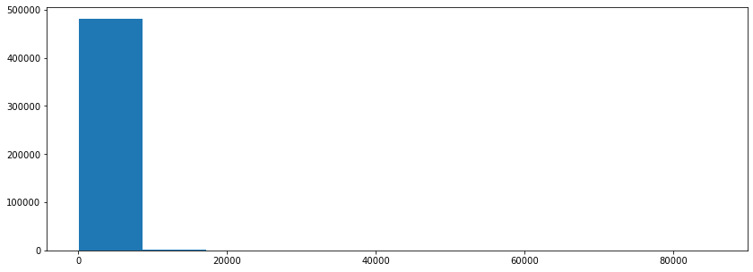

```python
bins = np.arange(0,bikeshare_master['duration_sec'].max()+50,50)
plt.figure(figsize=(14,5))
plt.hist(data = bikeshare_master,x='duration_sec',bins=10);
```

> To have a more intuitive understanding of the graph i will convert the duration seconds to minutes and set an x axis limit because some values have a large margin

```python
# converting the duration seconds to minutes
bikeshare_master['duration_min'] = bikeshare_master['duration_sec']/60
```

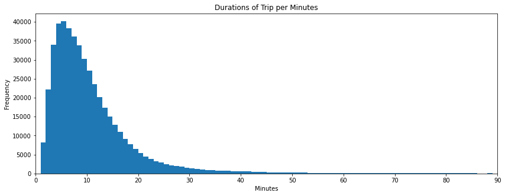

```python
bins = np.arange(0,bikeshare_master['duration_min'].max(),1)
plt.figure(figsize=(14,5))
plt.hist(data = bikeshare_master,x='duration_min',bins=bins)
plt.xlim(0,90)
plt.xlabel('Minutes')
plt.ylabel('Frequency')
plt.title('Durations of Trip per Minutes');
```

### Plot to investigate the distribution of frequency of trips in the first quarter of the year

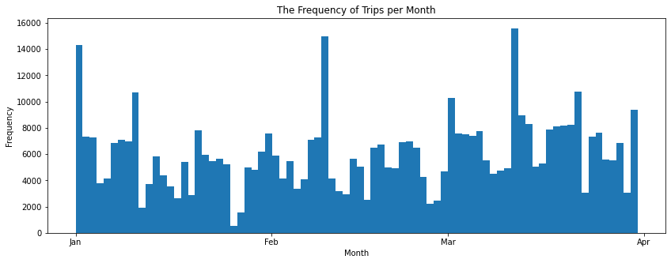

```python
fig,ax = plt.subplots(figsize=(14,5))
ax.hist(data = bikeshare_master,x='start_date',bins=80)
ax.set_xlabel('Month')
ax.set_ylabel('Frequency')
ax.set_title('The Frequency of Trips per Month');
date_form = DateFormatter("%b")
ax.xaxis.set_major_locator(mdates.MonthLocator())
ax.xaxis.set_major_formatter(date_form)
```

> From visual assessment we can denote that from January to March there is a sudden peak or surge of trips just before midweek of each month.

### Plot to explore the hour of the day with high demand for bikes

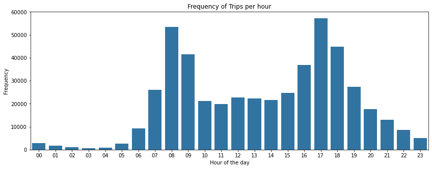

```python
data = pd.DataFrame(bikeshare_master['start_hour'].sort_values(),columns=['start_hour'])
plt.figure(figsize=(14,5))
sb.countplot(data = data,x='start_hour',color=sb.color_palette()[0])
plt.xlabel('Hour of the day')
plt.ylabel('Frequency')
plt.title('Frequency of Trips per hour');
```

> The distribution of this bar graph is bimodal which means in each day there will be two periods in time with very high demands for bikes. The two hours of the day with highest demands are 5PM and 8AM respectively.

### Plot to explore the day of the week with the most demands for bikes

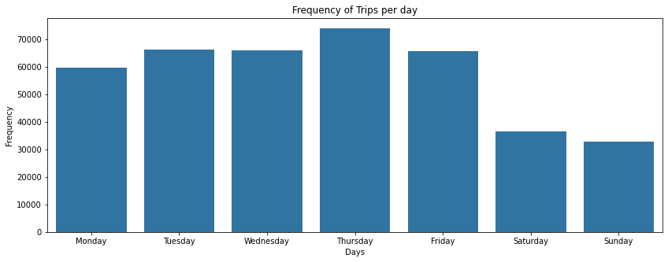

```python
plt.figure(figsize=(14,5))
sb.countplot(data =bikeshare_master,x='start_day',color=sb.color_palette()[0],order=[ 'Monday', 'Tuesday', 'Wednesday', 'Thursday', 'Friday', 'Saturday', 'Sunday'])
plt.xlabel('Days')
plt.ylabel('Frequency')
plt.title('Frequency of Trips per day');
```

> The bar graph show a rise in demand from the start of the week until weekends, which means alot of the users are commuters going to work other than for recreation

### Plot to identify the Top 20 neighbourhood with the most demand for bikes

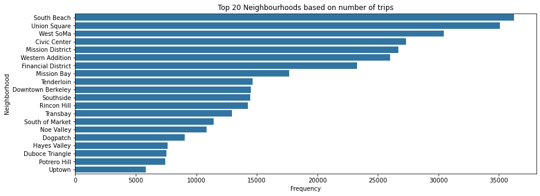

```python
top_20 = bikeshare_master['start_neighbourhood'].value_counts()[:-63]
top_20 = pd.DataFrame(top_20)
plt.figure(figsize=(14,5))
sb.barplot(data =top_20,y=top_20.index,x=top_20.start_neighbourhood,color=sb.color_palette()[0])
plt.xlabel('Frequency')
plt.ylabel('Neighborhood')
plt.title('Top 20 Neighbourhoods based on number of trips')
```

> We can see that south beach and union square seems to be the outstanding neighbourhood in terms of demand for bikes with over 35,000 trips in each of both neighbourhoods

### Plot to identify the Top 20 stations with the most demand for bikes

[figure not shown]

```python
top_20 = bikeshare_master['start_station_id'].value_counts()[:-269]
top_20 = pd.DataFrame(top_20)
plt.figure(figsize=(14,5))
sb.barplot(data =top_20,y=top_20.index,x=top_20.start_station_id,color=sb.color_palette()[0])
plt.xlabel('Frequency')
plt.ylabel('Station Id')
plt.title('Top 20 Start Stations based on number of trips')
```

> Market St at 10th St with the station id 58 is the station with the higest demands for bikes

### Plot to identify the Top 20 stations with the most destinations at the end of trip

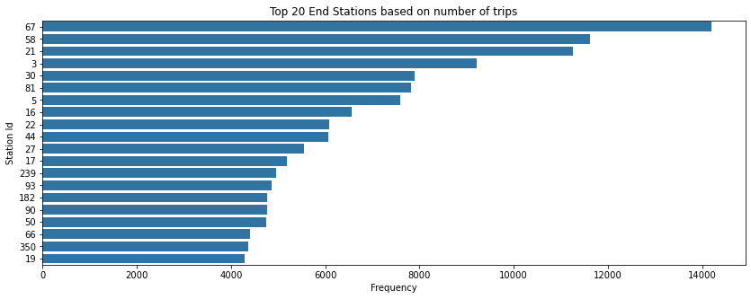

```python
top_20 = bikeshare_master['end_station_id'].value_counts()[:-268]
top_20 = pd.DataFrame(top_20)
plt.figure(figsize=(14,5))
sb.barplot(data =top_20,y=top_20.index,x=top_20.end_station_id,color=sb.color_palette()[0])
plt.xlabel('Frequency')
plt.ylabel('Station Id')
plt.title('Top 20 End Stations based on number of trips')
```

> San Francisco Caltrain Station 2 (Townsend St at 4th St) with a station id of 67 seams to be the station with highest number destination

### Plot to investigate the distance covered by each rider from the start station to the end station

```
(0.0, 10.0)
```

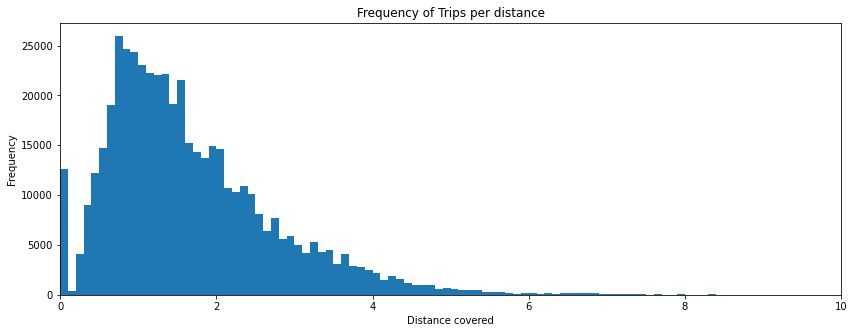

```python
bins = np.arange(0,bikeshare_master['distances(km)'].max()+0.1,0.1)
plt.figure(figsize=(14,5))
plt.hist(data = bikeshare_master,x='distances(km)',bins=bins)
plt.xlabel('Distance covered')
plt.ylabel('Frequency')
plt.title('Frequency of Trips per distance');
plt.xlim(0,10)
```

> The graph is positively skewed with the interpretation that frequency of the distance from the start and end station(s) decreases with an increase in distance after a range between 0 to 1 kilometre. Which means most users tends to end their trip at a station not more than 2 kilometres from the start station.

### A pie chart to distinguish the proportion of bikeshare usage between each cities

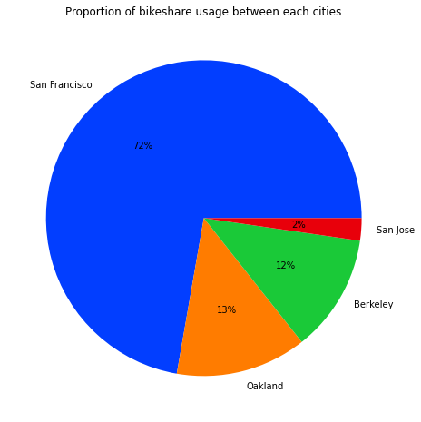

```python
data = bikeshare_master['start_city'].value_counts()
value = list(data.values)
city = list(data.index)
plt.figure(figsize=(16,8))
plt.pie(data =data,x=value,labels=city,colors=sb.color_palette('bright'), autopct='%.0f%%')
plt.title('Proportion of bikeshare usage between each cities')
```

> San Francisco seems to be the major city were the Ford Gobike system is being used with 72% of the total number of trips in the nation.

### A pie chart to distinguish the proportion between the type of users of the bikeshare system

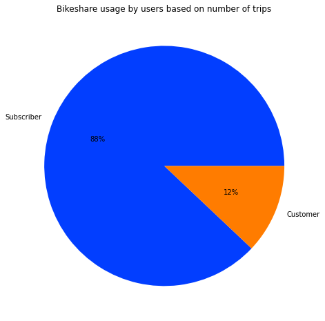

```python
data = bikeshare_master['user_type'].value_counts()
value = list(data.values)
usertype = list(data.index)
plt.figure(figsize=(16,8))
plt.pie(data =data,x=value,labels=usertype,colors=sb.color_palette('bright'), autopct='%.0f%%')
plt.title('Bikeshare usage by users based on number of trips')
```

> Subscribers seems to be the major users of the Ford Gobike system with 88% of the total number of trips

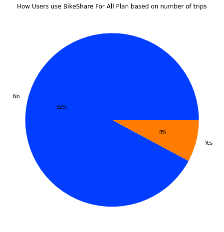

```python
data = bikeshare_master['bike_share_for_all_trip'].value_counts()
value = list(data.values)
city = ['No','Yes']
plt.figure(figsize=(16,8))
plt.pie(data =data,x=value,labels=city,colors=sb.color_palette('bright'), autopct='%.0f%%')
plt.title('How Users use BikeShare For All Plan based on number of trips')
```

> The BikeShare For All program is a low-income membership used to discount prices to help expand transportation access to underserved communities. So only a small population of the nation use this program which is 8% of the total number of trips

## Bivariate Exploration

```python
bikeshare_master.sample(6).T
```

|  | 453674 | 35811 | 538195 | 358405 | 154942 | 466370 |
| --- | --- | --- | --- | --- | --- | --- |
| duration_sec | 170 | 467 | 202 | 946 | 351 | 900 |
| start_time | 2019-03-22 08:45:17.983000 | 2019-01-28 08:42:47.080000 | 2019-03-13 15:30:01.210000 | 2019-02-04 18:05:15.433000 | 2019-01-08 19:09:53.478000 | 2019-03-20 21:40:45.872000 |
| end_time | 2019-03-22 08:48:08.783000 | 2019-01-28 08:50:34.374000 | 2019-03-13 15:33:23.376000 | 2019-02-04 18:21:02.131000 | 2019-01-08 19:15:45.411000 | 2019-03-20 21:55:46.019000 |
| start_station_id | 67 | 195 | 25 | 133 | 245 | 52 |
| start_station_name | San Francisco Caltrain Station 2 (Townsend St... | Bay Pl at Vernon St | Howard St at 2nd St | Valencia St at 22nd St | Downtown Berkeley BART | McAllister St at Baker St |
| start_station_latitude | 37.776639 | 37.812314 | 37.787522 | 37.755213 | 37.870139 | 37.777416 |
| start_station_longitude | -122.395526 | -122.260779 | -122.397405 | -122.420975 | -122.268422 | -122.441838 |
| end_station_id | 90 | 7 | 349 | 115 | 266 | 350 |
| end_station_name | Townsend St at 7th St | Frank H Ogawa Plaza | Howard St at Mary St | Jackson Playground | Parker St at Fulton St | 8th St at Brannan St |
| end_station_latitude | 37.771058 | 37.804562 | 37.78101 | 37.765026 | 37.862464 | 37.771431 |
| end_station_longitude | -122.402717 | -122.271738 | -122.405666 | -122.398773 | -122.264791 | -122.405787 |
| bike_id | 4600 | 1115 | 5008 | 3279 | 287 | 4569 |
| user_type | Subscriber | Subscriber | Subscriber | Subscriber | Subscriber | Subscriber |
| bike_share_for_all_trip | No | No | No | No | No | No |
| start_neighbourhood | South Beach | Westlake | Transbay | Liberty Street Historic District | Downtown Berkeley | Western Addition |
| start_city | San Francisco | Oakland | San Francisco | San Francisco | Berkeley | San Francisco |
| end_neighbourhood | West SoMa | Downtown | West SoMa | Potrero Hill | LeConte | West SoMa |
| end_city | San Francisco | Oakland | San Francisco | San Francisco | Berkeley | San Francisco |
| distances(km) | 0.886047 | 1.292936 | 1.025673 | 2.23914 | 0.909777 | 3.244814 |
| start_date | 2019-03-22 | 2019-01-28 | 2019-03-13 | 2019-02-04 | 2019-01-08 | 2019-03-20 |
| start_hour | 08 | 08 | 15 | 18 | 19 | 21 |
| start_day | Friday | Monday | Wednesday | Monday | Tuesday | Wednesday |

### Plot to explore the total duration of trip for each day in the first quarter of the year

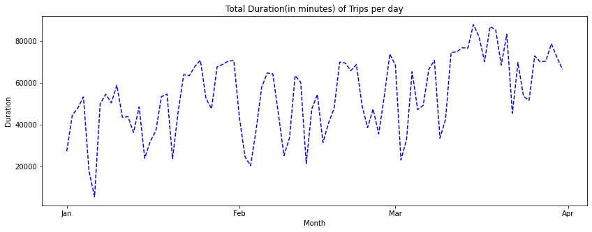

```python
fig,ax = plt.subplots(figsize=(14,5))
c = bikeshare_master[['start_date','duration_min']].groupby('start_date').sum()
ax.plot(c.index,c['duration_min'],'b--')
ax.set_xlabel('Month')
ax.set_ylabel('Duration')
ax.set_title('Total Duration(in minutes) of Trips per day');
date_form = DateFormatter("%b")
ax.xaxis.set_major_locator(mdates.MonthLocator())
ax.xaxis.set_major_formatter(date_form)
```

> Even though there are variations in the trends we can still see an increase in peak of duration from january to march.

### Plot to explore the average duration of trip for each day in the first quarter of the year

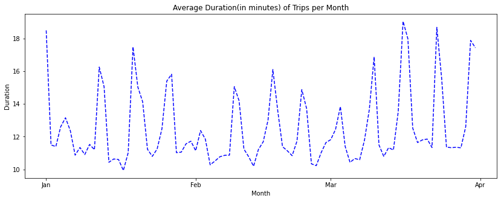

```python
fig,ax = plt.subplots(figsize=(14,5))
c = bikeshare_master[['start_date','duration_min']].groupby('start_date').mean()
ax.plot(c.index,c['duration_min'],'b--')
ax.set_xlabel('Month')
ax.set_ylabel('Duration')
ax.set_title('Average Duration(in minutes) of Trips per Month');
date_form = DateFormatter("%b")
ax.xaxis.set_major_locator(mdates.MonthLocator())
ax.xaxis.set_major_formatter(date_form)
```

> from the line graph we can see that the peaks of average duration in january is higher than that of february with march greater than both

### Plot for discussing the hour of the day with the highest total duration

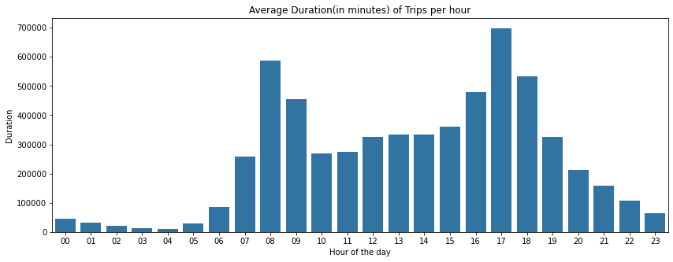

```python
c = bikeshare_master[['start_hour','duration_min']].groupby('start_hour').sum().reset_index()
plt.figure(figsize=(14,5))
sb.barplot(data = c,x=c['start_hour'],y=c['duration_min'],color=sb.color_palette()[0])
plt.xlabel('Hour of the day')
plt.ylabel('Duration')
plt.title('Average Duration(in minutes) of Trips per hour');
```

> We can see that just like the frequency graph above for hour of the day with highest demand for bikes this graph also is bimodal and identical to the one above. The two hours of the day with highest total duration are 5PM and 8AM respectively.

### Plot for discussing the hour of the day with the highest average duration

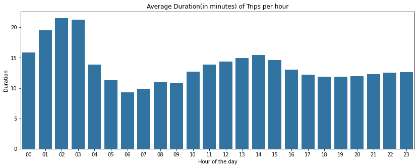

```python
c = bikeshare_master[['start_hour','duration_min']].groupby('start_hour').mean().reset_index()
plt.figure(figsize=(14,5))
sb.barplot(data = c,x=c['start_hour'],y=c['duration_min'],color=sb.color_palette()[0])
plt.xlabel('Hour of the day')
plt.ylabel('Duration')
plt.title('Average Duration(in minutes) of Trips per hour');
```

> The hours of the day with the highest average durations are within the range of 12AM to 4AM which is strange to me. That means bikeshare users spend more minutes on a trip from beginning of the day.

### Plot for investigating the day of the week with the highest average duration

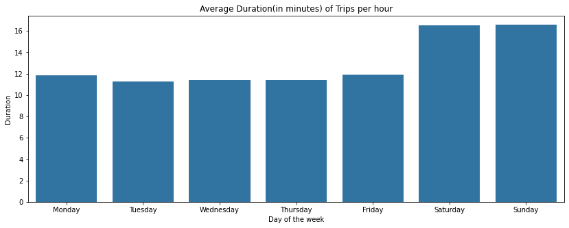

```python
c = bikeshare_master[['start_day','duration_min']].groupby('start_day').mean().reset_index()
plt.figure(figsize=(14,5))
sb.barplot(data = c,x=c['start_day'],y=c['duration_min'],color=sb.color_palette()[0],order=[ 'Monday', 'Tuesday', 'Wednesday', 'Thursday', 'Friday', 'Saturday', 'Sunday'])
plt.xlabel('Day of the week')
plt.ylabel('Duration')
plt.title('Average Duration(in minutes) of Trips per hour');
```

> Saturdays and Sundays seems to be the days with the highest average durations which not coincidentally is a weekend. Users spend more time on trips during the weekend maybe for recreation or for visitation and some sort.

### Plot for investigating the day of the week with the highest total duration

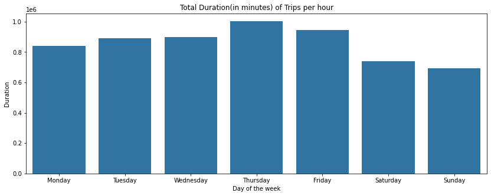

```python
c = bikeshare_master[['start_day','duration_min']].groupby('start_day').sum().reset_index()
plt.figure(figsize=(14,5))
sb.barplot(data = c,x=c['start_day'],y=c['duration_min'],color=sb.color_palette()[0],order=[ 'Monday', 'Tuesday', 'Wednesday', 'Thursday', 'Friday', 'Saturday', 'Sunday'])
plt.xlabel('Day of the week')
plt.ylabel('Duration')
plt.title('Total Duration(in minutes) of Trips per hour');
```

> This bar graph is unimodal with thursday being the day with the highest total duration and weekdays have more total durations than weekends because of the population of commuters using the bikes to go to work

### Plot to identify stations with high total durations for the first quarter of the year

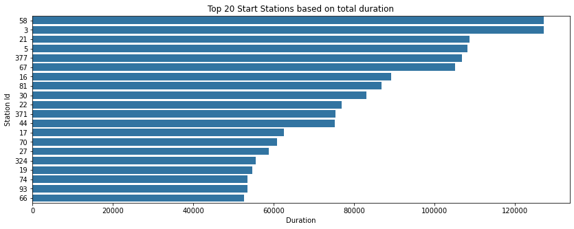

```python
top_20 = bikeshare_master[['start_station_id','duration_min']].groupby('start_station_id').sum().reset_index().sort_values('duration_min',ascending=False)[:-269]
plt.figure(figsize=(14,5))
sb.barplot(data = top_20,x=top_20['duration_min'],y=top_20['start_station_id'],color=sb.color_palette()[0])
plt.xlabel('Duration')
plt.ylabel('Station Id')
plt.title('Top 20 Start Stations based on total duration')
```

> Based on the total durations and number of rentals of bike for the first quarter managers can be able to predict revenue to be made. Market St at 10th St with the station id 58 and Powell St BART Station (Market St at 4th St) with the station id 3 are the stations with the most total durations for the first quarter of the year, Market St at 10th St has the highest demand for bikes and has the most total duration which alot of revenue is being generated from this station.

### The proportion between the type of users of the bikeshare system based on the duration

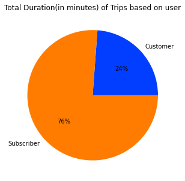

```python
c = bikeshare_master[['user_type','duration_min']].groupby('user_type').sum().reset_index()
plt.figure(figsize=(14,5))
plt.pie(data = c,x=c['duration_min'],labels=c['user_type'],colors=sb.color_palette('bright'), autopct='%.0f%%')
plt.title('Total Duration(in minutes) of Trips based on user');
```

> Based on the total duration of trips in the first quarter of the year subscribers has atleast 76% of the total duration making them the major users.

### The proportion between the city using the bikeshare system based on the duration

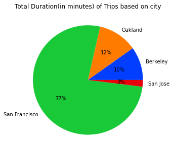

```python
c = bikeshare_master[['start_city','duration_min']].groupby('start_city').sum().reset_index()
plt.figure(figsize=(14,5))
plt.pie(data = c,x=c['duration_min'],labels=c['start_city'],colors=sb.color_palette('bright'), autopct='%.0f%%')
plt.title('Total Duration(in minutes) of Trips based on city');
```

> Based on the total duration of trips in the first quarter of the year San Francisco has atleast 77% of the total duration making the city the major users.

### Plot to explore the average duration spent on trips by users

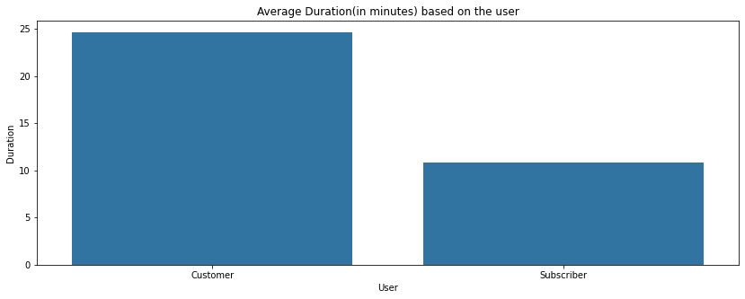

```python
c = bikeshare_master[['user_type','duration_min']].groupby('user_type').mean().reset_index()
plt.figure(figsize=(14,5))
sb.barplot(data = c,x=c['user_type'],y=c['duration_min'],color=sb.color_palette()[0])
plt.xlabel('User')
plt.ylabel('Duration')
plt.title('Average Duration(in minutes) based on the user');
```

> Customers tend to spent more than double the minutes subscribers spend on trips

### Plot to discover the hour of the day users travel more distance from start station to end station

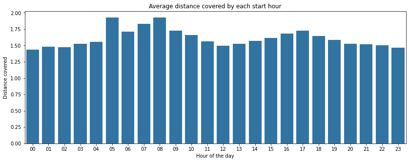

```python
c = bikeshare_master[['start_hour','distances(km)']].groupby('start_hour').mean().reset_index()
plt.figure(figsize=(14,5))
sb.barplot(data = c,x=c['start_hour'],y=c['distances(km)'],color=sb.color_palette()[0])
plt.xlabel('Hour of the day')
plt.ylabel('Distance covered')
plt.title('Average distance covered by each start hour')
```

> Users tend to travel more distance from start station to end station from 5AM to 8AM

### Plot to discover the day with the most distance from start station to end station

```
(-0.5, 10.0)
```

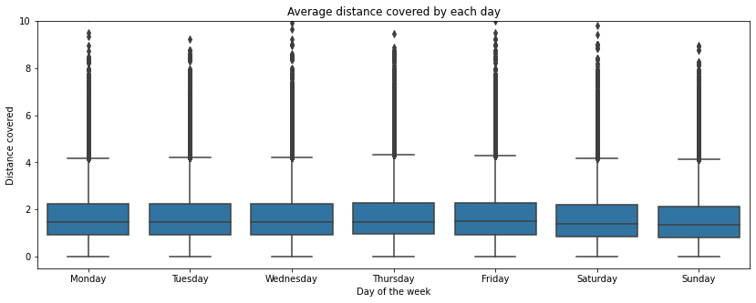

```python
plt.figure(figsize=(14,5))
sb.boxplot(data = bikeshare_master,x='start_day',y='distances(km)',color=sb.color_palette()[0],order=[ 'Monday', 'Tuesday', 'Wednesday', 'Thursday', 'Friday', 'Saturday', 'Sunday'])
plt.xlabel('Day of the week')
plt.ylabel('Distance covered')
plt.title('Average distance covered by each day')
plt.ylim(-0.5,10)
```

> The mean and median distances are similar from weekdays to weekends which means the day of the week is not a factor affecting distance covered

### Plot to explore the average distance covered by each type of user from start station to end station

```
(-0.5, 10.0)
```

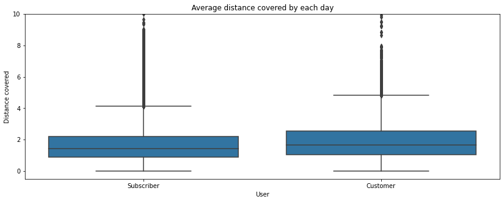

```python
plt.figure(figsize=(14,5))
sb.boxplot(data = bikeshare_master,x='user_type',y='distances(km)',color=sb.color_palette()[0])
plt.xlabel('User')
plt.ylabel('Distance covered')
plt.title('Average distance covered by each day')
plt.ylim(-0.5,10)
```

> Customers have an average distance a little more than subscribers which doesn't really distinguish much about them

### Plot to determine the hour of the day with the highest demand for bikes based on type of user

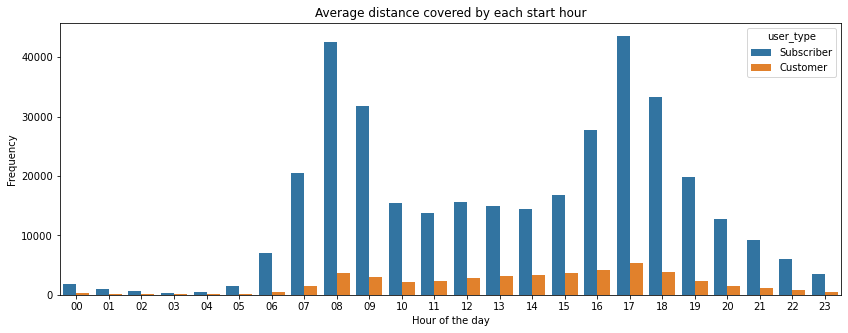

```python
plt.figure(figsize=(14,5))
sb.countplot(data = bikeshare_master.sort_values('start_hour'),x='start_hour',hue='user_type')
plt.xlabel('Hour of the day')
plt.ylabel('Frequency')
plt.title('Average distance covered by each start hour')
```

> Subscribers tend to have a higher demand for bike than customers for every hour of the day

### Plot to determine the day of the week with the highest demand for bikes based on type of users

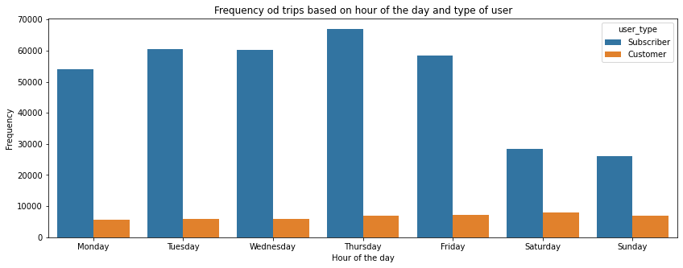

```python
plt.figure(figsize=(14,5))
sb.countplot(data = bikeshare_master,x='start_day',hue='user_type',order=[ 'Monday', 'Tuesday', 'Wednesday', 'Thursday', 'Friday', 'Saturday', 'Sunday'])
plt.xlabel('Hour of the day')
plt.ylabel('Frequency')
plt.title('Frequency od trips based on hour of the day and type of user')
```

> Subscribers tend to have a higher demand for bike than customers for every day of the week

### Plot to identify the relationship between type of user and bikeshare for all trip membership plan

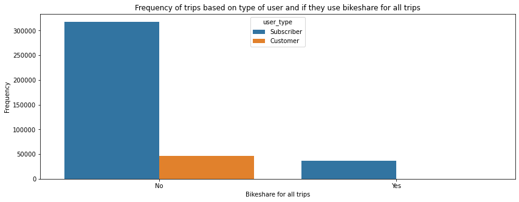

```python
plt.figure(figsize=(14,5))
sb.countplot(data = bikeshare_master,x='bike_share_for_all_trip',hue='user_type')
plt.xlabel('Bikeshare for all trips')
plt.ylabel('Frequency')
plt.title('Frequency of trips based on type of user and if they use bikeshare for all trips')
```

> For this bar graph most subscribers don't use bike share for all trip plan, customers don't use bikeshare for all trip plan. 'BikeShare For All' program is the nation’s most comprehensive bike share equity program, includes equitable station siting, outreach, and discounted pricing to help expand transportation access to underserved communities.

## Multivariate Exploration

### Plot to investigate the duration of trips by the different users per month

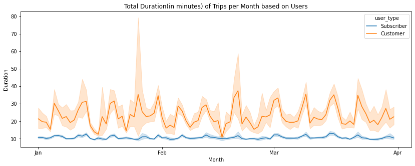

```python
fig,ax = plt.subplots(figsize=(14,5))
ax.set_xlabel('Month')
ax.set_ylabel('Duration')
ax.set_title('Total Duration(in minutes) of Trips per Month based on Users');
date_form = DateFormatter("%b")
ax.xaxis.set_major_locator(mdates.MonthLocator())
ax.xaxis.set_major_formatter(date_form)
sb.lineplot(data=bikeshare_master, x="start_date", y="duration_min",hue='user_type')
```

> From the line graph subscribers seem to have constant duration of trip with range just around 10 minutes. Customers have higher duration of trips ranging from approximately 10 minutes to 35 minutes

### Plot to explore the duration of trips of different users at each hour of the day

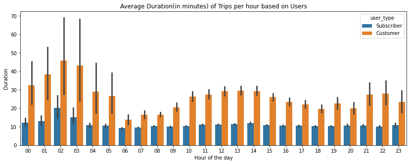

```python
plt.figure(figsize=(14,5))
sb.barplot(data = bikeshare_master.sort_values('start_hour'),x='start_hour',y='duration_min',hue='user_type')
plt.xlabel('Hour of the day')
plt.ylabel('Duration')
plt.title('Average Duration(in minutes) of Trips per hour based on Users');
```

> Customers tend to have a higher duration of trips than Subscribers for every hour of the day

### Plot to explore the average duration of trips of different users at each day of the week

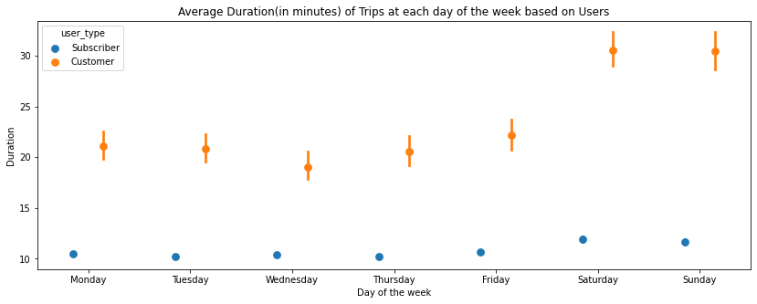

```python
plt.figure(figsize=(14,5))
sb.pointplot(data = bikeshare_master,x='start_day',y='duration_min',hue='user_type',order=[ 'Monday', 'Tuesday', 'Wednesday', 'Thursday', 'Friday', 'Saturday', 'Sunday'],dodge = 0.3, linestyles = "")
plt.xlabel('Day of the week')
plt.ylabel('Duration')
plt.title('Average Duration(in minutes) of Trips at each day of the week based on Users');
```

> Customers tend to have a higher duration of trips than Subscribers for every day of the week

### Plot to explore the duration of trips of different users at each city

```
(0.0, 50.0)
```

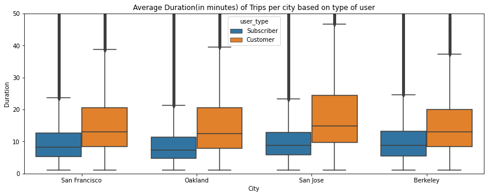

```python
plt.figure(figsize=(14,5))
sb.boxplot(data = bikeshare_master,x='start_city',y='duration_min',hue='user_type')
plt.xlabel('City')
plt.ylabel('Duration')
plt.title('Average Duration(in minutes) of Trips per city based on type of user');
plt.ylim(0,50)
```

### Plot to explore the time of the day different users demand bikes

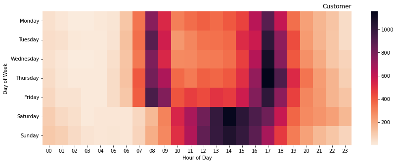

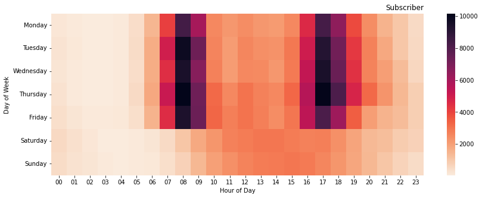

```python
plt.suptitle('Hourly Usage during Weekdays for Customers and Subscribers')
fig,ax1 = plt.subplots(figsize=(14,5))
customers = bikeshare_master.query('user_type == "Customer"')
customers = customers.groupby(['start_day', 'start_hour']).size()
customers = customers.reset_index(name='count')
customers = customers.pivot(index='start_day', columns='start_hour', values='count')
sb.heatmap(customers, cmap='rocket_r',ax=ax1);
plt.title('Customer', loc='right');
plt.xlabel('Hour of Day');
plt.ylabel('Day of Week');

fig,ax2 = plt.subplots(figsize=(14,5))
subscribers = bikeshare_master.query('user_type == "Subscriber"')
subscribers = subscribers.groupby(['start_day', 'start_hour']).size()
subscribers = subscribers.reset_index(name='count')
subscribers = subscribers.pivot(index='start_day', columns='start_hour', values='count')
sb.heatmap(subscribers, cmap='rocket_r',ax=ax2);
plt.title('Subscriber', loc='right');
plt.xlabel('Hour of Day');
plt.ylabel('Day of Week');
```